# The Front Page of the Internet

Sam Zielinski

# The Front Page of the Internet

## Overview

For my research, I went onto the popular website, reddit, and surveyed the front page at various times of the day over the course of a couple days, making sure to record the title, subreddit, purpose, media type, upvotes, subject, and hours since uploaded. Since reddit is a very popluar site, I thought it would be intersting to see what types of trends occur in what subjects people like and respond to, and look at any reoccuring patterns in what apears on the front page of reddit. I was also interested in seeing if their is any correlation between how many upvotes something got and how long it was up for, when it was posted, and when it was on the frot page.

## Data dictionary

Here is a data dictionary for the reddit dataset:

- **post_title**: Character variable telling the title of the post
- **subreddit**: Character variable telling the sub reddit that the post was originally posted too.
- **user**: Character variable telling the username of the original poster.
- **media_type**:Categorical character variable telling the type of media the post uses.
  - picture: post has an attached image
  - gif: post has an attached gif
  - video: post has an attached video
  - article: post has a link to an external article
  - text: post contains only text
- **purpose**: Categorical character variable telling the intended purpose of the post.
  - funny: intended to make people laugh
  - cool/intersting: funfacts, interesting videos, and other odd things that aren’t quite educational but entertaining
  - news: current evernts and news
  - educational: posts intended to teach the reader something new and substantial
- **time_uploaded**: Numerical variable showing how many hours ago the post was uploaded.
- **time_checked**: Numerical variable showing the time that when the data on the post was collected.
- **upvotes**: Numerical variable how many upvotes (likes) the post recieved.
- **content**:Categorical character variable telling the subject matter of the content.
  - animals: posts containing animals
  - celebrities: posts about celebrities
  - movies/tv: posts pertaining to Tv and movies
  - politics: posts about current events in politics
  - world/art: posts showing art, nature, and other cultures
  - science/technology: posts about currnet science and technology
  - gaming: posts about video games
  - sports: posts about sports
  - advice: posts giving advice, wisdom, or philosophy
  - history: posts about history
  - social media: posts that contain other posts from social media
  - extraordinary people: posts that include normal people doing extraordinary things
  - comics: posts that contain comic strips
  - other: posts that do not quite fit into the other categories

Which can be read in as follows:

```r
reddit <- read_csv("https://raw.githubusercontent.com/urstats/stat209-s18-samueltz/master/stats_project_1_sam_zielinski.csv")
reddit
```

| post_title | subreddit | user | media_type | purpose | time_uploaded | time_checked | upvotes | content |
| --- | --- | --- | --- | --- | --- | --- | --- | --- |
| absolute madness | madlads | timmie_tams | picture | funny | 2 | 13:30:00 | 20100 | social media |
| welcome to mars - real picture from mars rover | space | CedrikG | picture | educational | 4 | 13:30:00 | 20500 | science/technology |
| my work continues the paint lines up the wall to help people park | mildlyinteresting | Cindypi13 | picture | cool/interesting | 4 | 13:30:00 | 54500 | other |
| Please bring your chairs and tables to the upright position [L] | perfectloops | Lookur | gif | cool/interesting | 2 | 13:30:00 | 10200 | other |
| seems legit | aww | Hadestempo1 | gif | funny | 4 | 13:30:00 | 55000 | animals |
| Keanu Reeves being atatcked by a stuffed bear, 1980 | OldSchoolCool | albino_underhill | gif | funny | 3 | 13:30:00 | 18800 | celebrities |
| a wild young monkey is welcomed back by his family when he is released afer 3 weeks of treatment far a leg injury | gifs | namraka | gif | cool/interesting | 5 | 13:30:00 | 87000 | animals |
| a frinedly wager over cotton candy | youseeingthisshit | StrangerInTheAttic | gif | funny | 4 | 13:30:00 | 21500 | extraordinary people |
| every fucking time | BikiniBottomTwitter | zyyp | picture | funny | 4 | 13:30:00 | 10700 | movies/tv |
| rice field farmer ~ Thaoland | pics | jaxsonjames | picture | cool/interesting | 5 | 13:30:00 | 16200 | world/art |

[output cut: 68 more lines]

## Exploratory Analysis

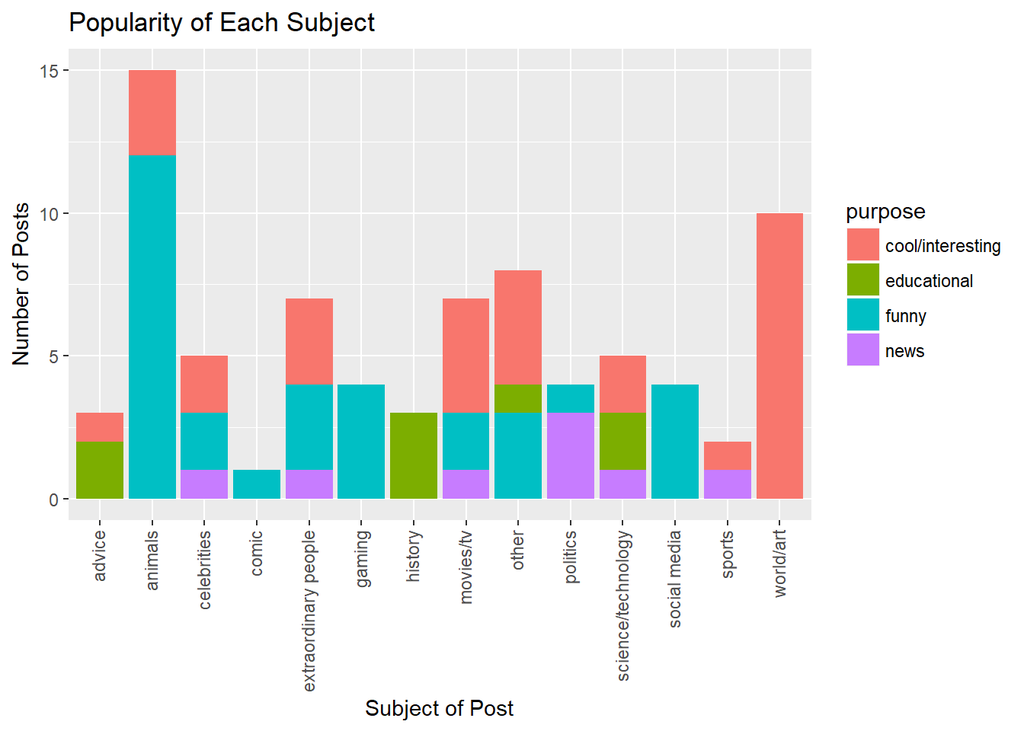

This first graph plots the amount of times each subject area came up, with a colorful fill to show the purpose of each post. Overall the graph shows that the most popular category was animals, followed by world/art, and other. The graph also shows that posts were mostly made with more mindless entertainment in mind, as the funny, cool, and interesting posts were most popular, while more serious posts were less common. This shows the nature of the website as a whole, being more for quick entertainment than a serious news outlet.

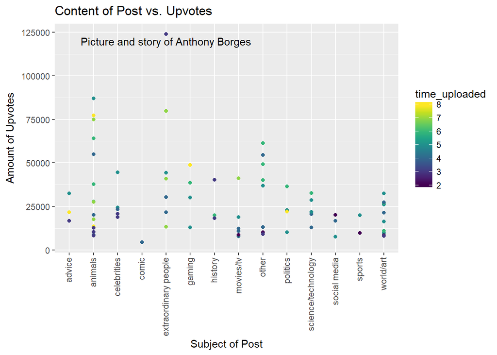

This next graph compared the same catagories of content, but compared them to the amount of upvotes each post recieved. The points were then colored to show how many hours ago the post was uploaded. The plot shows that animals, other, and extraordinary people recieved more average upvotes than than the other categories. The color gradient also showed that the longer the post had been up on the website, the more upvotes it recieved. One obvious outlier to this trend, however, is the post about a student who was shot holding a door closed during the recent school shooting in Florida. This shows that while the site has its focus on trivial and mundane entertainment, it still holds serious news in high regard.

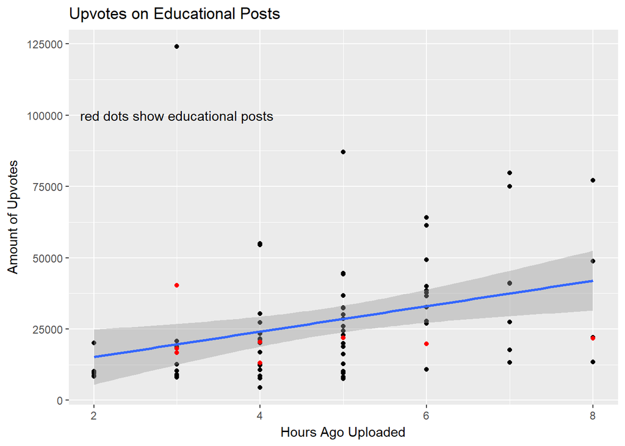

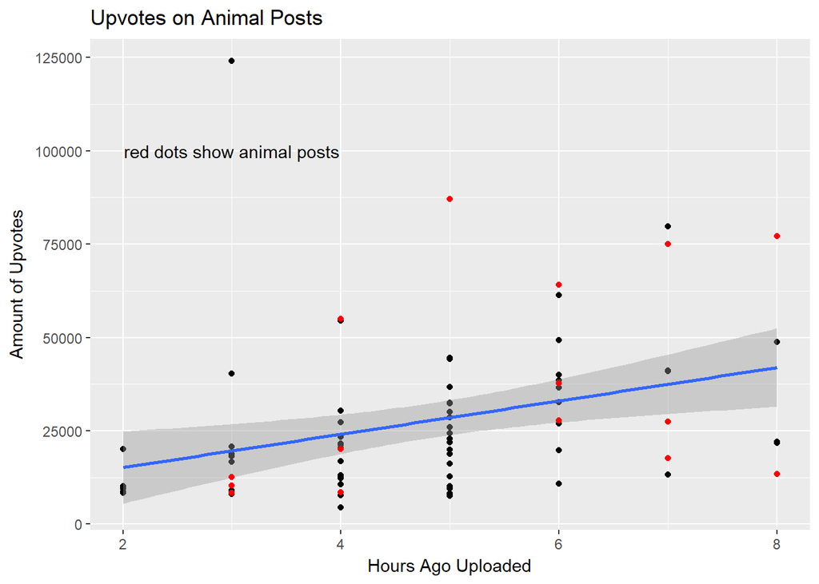

## Conclusion

From the data that I managed to gather, I found that the longer a post had been on the website, the more upvotes it had. I was also able to look at the tyes of posts that do well, such as funny posts and animals realted posts, and posts that did not fair so well, such as educational posts. This data shows that the people who use reddit are more focused on something lighthearted to give them some quick entertainment. With this being said, extraordinary posts, such as the post about the boy who acted heroically during the Florida school shooting recieved excpetionally more upvotes, showing that very important or serious news, while rare, is at the top of the front page.

## References

www.reddit.com